# Benchmarking STAR vs NovoAlign

Samantha Sevilla

3/4/2022

## Background

In this benchmarking experiment, STAR was compared to NOVOAlign, currently utilized in our iCLIP pipeline. STAR version 2.7.8a was used (https://github.com/alexdobin/STAR/releases).

For each read, an alignment was assessed for any gaps. Gaps greater than 100 were considered, with two possible outcomes:

1. alignment—gap—alignment
2. alignment—gap–insertion/deletion—alignment

For all reads that match outcome #1, overhang and parent were assigned to the alignments as follows:

3. overhang: the smaller length of the two alignments
4. parent: the larger length of the two alignments

Ratios were calculated for each read that met this criterion. For example #5 would have a ratio of 2/70, #6 would have a ratio of 2/70, and #7 would not be included due to the gap being <100.

5. alignment1(N=2)—gap(N=100)—alignment2(N=70)
6. alignment3(N=70)—gap(N=100)—alignment4(N=2)
7. alignment3(N=70)—gap(N=10)—alignment4(N=2)

To determine the best parameters to decrease the number of instances overhang scenerios similar to #5 above, several STAR parameters were implemented based on three sources:

- https://www.sciencedirect.com/science/article/pii/S1046202318304948
- https://www.encodeproject.org/documents/739ca190-8d43-4a68-90ce-1a0ddfffc6fd/@@download/attachment/eCLIP_analysisSOP_v2.2.pdf
- https://rnajournal.cshlp.org/content/22/1/1

From these sources, 16 alignments were performed using STAR, with 17 different parameters. To compare these parameters with current alignment parameters NOVOAlign was used, with three variations in addition to the standard method. Listed below are the STAR parameters used, summarized by FLAG used with it’s description, default settings, settings based on the Busch paper with unique alignments only (1A-C) and all reads (2A-I), settings based on ENCODE standards (Encode 1,2) and settings based on ClipSeqTools.

| Alignment Flag | Description |
| --- | --- |
| outFilterMismatchNoverReadLmax | max number of mismatches per pair relative to read length: for 2x100b, max number of mis- |
| matches is 0.04*200=8 for the paired read |  |
| outFilterMismatchNmax | alignment will be output only if it has no more mismatches than this value. |
| outFilterMultimapNmax | max number of multiple alignments allowed for a read: if exceeded, the read is considered unmapped |
| outSJfilterReads | which reads to consider for collapsed splice junctions output |
| outSJfilterCountTotalMin | minimum total (multi-mapping+unique) read count per junctionfor: (1) non-canonical motifs, (2) GT/AG and CT/AC motif, (3) GC/AG andCT/GC motif, (4) AT/AC and GT/AT motif. -1 means no output for thatmo… |
| alignEndsType | type of read ends alignment; fully extend only the 5p of the read1, all other ends: local alignment |
| outSAMunmapped | output of unmapped reads in the SAM format |
| outSAMattributes | a string of desired SAM attributes, in the order desired for the output SAM |
| outFilterType | keep only those reads that contain junctions that passed filtering into SJ.out.tab |
| outFilterScoreMin | alignment will be output only if its score is higher than or equal to this value. |
| outFilterMultimapScoreRange | the score range below the maximum score for multimapping alignments |
| sjdbScore | extra alignment score for alignments that cross database junctions |
| outSJfilterOverhangMin | minimum overhang length for splice junctions on both sides for: (1)non-canonical motifs, (2) GT/AG and CT/AC motif, (3) GC/AG and CT/GCmotif, (4) AT/AC and GT/AT motif. -1 means no output for that mot… |
| alignIntronMax | maximum intron length |
| outFilterMatchNmin | alignment will be output only if the number of matched bases is higher |
| than or equal to this value. |  |
| outFilterMatchNminOverLread | sam as outFilterMatchNmin, but normalized to the read length (sum of |
| mates’ lengths for paired-end reads). |  |
| alignSJDBoverhangMin | minimum overhang for annotated junctions |
| alignSJoverhangMin | minimum overhang for unannotated junctions |

| Alignment Flag | Default | star_1a | star_1b | star_1c | star_2a | star_2b | star_2c | star_2d | star_2e | star_2f | star_2g | star_2h | star_2i |
| --- | --- | --- | --- | --- | --- | --- | --- | --- | --- | --- | --- | --- | --- |
| outFilterMismatchNoverReadLmax | 0.04 | 0.04 | 0.05 | 0.02 | 0.04 | 0.05 | 0.02 | 0.04 | 0.04 | 0.04 | 0.04 | 0.04 | 0.04 |
| outFilterMismatchNmax | 999 | 999 | 999 | 999 | 999 | 999 | 999 | 999 | 999 | 999 | 999 | 999 | 999 |
| outFilterMultimapNmax | 20 | 1 | 1 | 1 | 999 | 999 | 999 | 999 | 999 | 999 | 999 | 999 | 999 |
| outSJfilterReads | All | Unique | Unique | Unique | All | All | All | All | All | All | All | All | All |
| outSJfilterCountTotalMin | 3 1 1 1 | 10 5 5 5 | 10 5 5 5 | 10 5 5 5 | 10 5 5 5 | 10 5 5 5 | 10 5 5 5 | 10 5 5 5 | 10 5 5 5 | 10 5 5 5 | 10 5 5 5 | 10 5 5 5 | 10 5 5 5 |
| alignEndsType | Local | Extend5pOfRead1 | Extend5pOfRead1 | Extend5pOfRead1 | Extend5pOfRead1 | Extend5pOfRead1 | Extend5pOfRead1 | Extend5pOfRead1 | Extend5pOfRead1 | Extend5pOfRead1 | Extend5pOfRead1 | Extend5pOfRead1 | EndToEnd |
| outSAMunmapped | None | None | None | None | None | None | None | None | None | None | None | None | None |
| outSAMattributes | Standard | Standard | Standard | Standard | Standard | Standard | Standard | Standard | Standard | Standard | Standard | Standard | Standard |
| outFilterType | Normal | Normal | Normal | Normal | Normal | Normal | Normal | Normal | Normal | Normal | Normal | Normal | Normal |
| outFilterScoreMin | 0 | 0 | 0 | 0 | 0 | 0 | 0 | 0 | 0 | 0 | 0 | 0 | 0 |
| outFilterMultimapScoreRange | 1 | 1 | 1 | 1 | 1 | 1 | 1 | 5 | 0 | 5 | 5 | 5 | 5 |
| sjdbScore | 2 | 0 | 0 | 0 | 0 | 0 | 0 | 0 | 0 | 0 | 0 | 0 | 0 |
| outSJfilterOverhangMin | 30 12 12 12 | 15 6 6 6 6 | 15 6 6 6 6 | 15 6 6 6 6 | 15 6 6 6 6 | 15 6 6 6 6 | 15 6 6 6 6 | 15 6 6 6 6 | 15 6 6 6 6 | 15 6 6 6 6 | 15 6 6 6 6 | 20 10 10 10 10 | 15 6 6 6 6 |
| alignIntronMax | 1000000 | 1000000 | 1000000 | 1000000 | 1000000 | 1000000 | 1000000 | 1000000 | 1000000 | 1000000 | 1000000 | 1000000 | 1000000 |
| outFilterMatchNmin | 10 | 10 | 10 | 10 | 10 | 10 | 10 | 10 | 10 | 10 | 10 | 10 | 10 |
| outFilterMatchNminOverLread | 0.6 | 0.6 | 0.6 | 0.6 | 0.6 | 0.6 | 0.6 | 0.6 | 0.6 | 0.6 | 0.6 | 0.6 | 0.6 |
| alignSJDBoverhangMin | 3 | 5 | 5 | 5 | 5 | 5 | 5 | 5 | 5 | 5 | 5 | 5 | 5 |
| alignSJoverhangMin | 5 | 5 | 5 | 5 | 5 | 5 | 5 | 5 | 5 | 5 | 5 | 5 | 5 |

| Alignment Flag | Default | star_encode1 | star_encode2 | star_clipseqtools_v1 | star_clipseqtools_v2 |
| --- | --- | --- | --- | --- | --- |
| outFilterMismatchNoverReadLmax | 0.04 | 0.04 | 0.04 | 0.04 | 0.04 |
| outFilterMismatchNmax | 999 | 999 | 999 | 999 | 999 |
| outFilterMultimapNmax | 20 | 30 | 1 | 20 | 20 |
| outSJfilterReads | All | All | All | All | All |
| outSJfilterCountTotalMin | 3 1 1 1 | 10 5 5 5 | 10 5 5 5 | 3 1 1 1 | 3 1 1 1 |
| alignEndsType | Local | EndToEnd | EndToEnd | Local | Local |
| outSAMunmapped | None | Within | Within | None | None |
| outSAMattributes | Standard | All | All | All | All |
| outFilterType | Normal | BySJout | BySJout | Normal | Normal |
| outFilterScoreMin | 0 | 10 | 10 | 0 | 0 |
| outFilterMultimapScoreRange | 1 | 1 | 1 | 0 | 0 |
| sjdbScore | 2 | 0 | 0 | 2 | 2 |
| outSJfilterOverhangMin | 30 12 12 12 | 15 6 6 6 6 | 15 6 6 6 6 | 30 12 12 12 | 30 12 12 12 |
| alignIntronMax | 1000000 | 1000000 | 1000000 | 50000 | 1000000 |
| outFilterMatchNmin | 10 | 10 | 10 | 15 | 15 |
| outFilterMatchNminOverLread | 0.6 | 0.6 | 0.6 | 0.9 | 0.9 |
| alignSJDBoverhangMin | 3 | 1 | 1 | 5 | 5 |
| alignSJoverhangMin | 5 | 8 | 8 | 5 | 5 |

|  | Alignment Flag | Default | novo_test5 | novo_1 | novo_2 | novo_3 |
| --- | --- | --- | --- | --- | --- | --- |
| 19 | p | -1 | -1 | -1 | -1 | -1 |
| 20 | H | off | off | 22 | 22 | 22 |
| 21 | g | 40 | 40 | 40 | 40 | 40 |
| 22 | x | 6 | 6 | 6 | 6 | 6 |
| 23 | matchreward | 8 | 8 | 4 | 20 | 20 |
| 24 | slidingwindow | 0,0 | 0,0 | 9,9 | 9,9 | 9,9 |
| 25 | softclip | 0,0 | 0,0 | 40,25 | 0,0 | 100,100 |
| 26 | hlimit | 9 | 9 | 8 | 8 | 8 |
| 27 | s | 2 | 2 | 2 | 2 | 2 |
| 28 | R | 5 | 5 | 5 | 5 | 1 |
| 29 | r | None | EXHAUSTIVE 999 | EXHAUSTIVE 999 | EXHAUSTIVE 999 | EXHAUSTIVE 999 |

## Summary Tables

Summary table of alignment variation by the length of overhang or length of gap. Values indicate the number of times this feature was observed.

|  | id | 1 | 2 | 4 | 6 | 7 | 12 | 35 | 36 | totals |
| --- | --- | --- | --- | --- | --- | --- | --- | --- | --- | --- |
| 1 | novo_original | 288 | 710 | 349 | 0 | 7 | 0 | 0 | 7 | 1361 |
| 2 | novo_set1 | 289 | 710 | 351 | 0 | 7 | 0 | 3 | 4 | 1364 |
| 3 | novo_set2 | 288 | 942 | 120 | 4 | 0 | 0 | 3 | 4 | 1361 |
| 4 | novo_set3 | 128 | 74 | 1164 | 0 | 7 | 0 | 3 | 4 | 1380 |
| 5 | star_1A | 0 | 0 | 0 | 0 | 0 | 1 | 0 | 7 | 8 |
| 13 | star_1b | 0 | 0 | 0 | 0 | 0 | 0 | 0 | 7 | 7 |
| 14 | star_1c | 0 | 0 | 0 | 0 | 0 | 0 | 0 | 7 | 7 |
| 6 | star_2a | 0 | 0 | 0 | 0 | 0 | 1 | 0 | 7 | 8 |
| 15 | star_2b | 0 | 0 | 0 | 0 | 0 | 0 | 0 | 7 | 7 |
| 16 | star_2c | 0 | 0 | 0 | 0 | 0 | 0 | 0 | 7 | 7 |
| 7 | star_2d | 0 | 0 | 0 | 0 | 0 | 1 | 0 | 7 | 8 |
| 8 | star_2e | 0 | 0 | 0 | 0 | 0 | 1 | 0 | 7 | 8 |
| 9 | star_2f | 0 | 0 | 0 | 0 | 0 | 1 | 0 | 7 | 8 |
| 10 | star_2g | 0 | 0 | 0 | 0 | 0 | 1 | 0 | 7 | 8 |
| 11 | star_2h | 0 | 0 | 0 | 0 | 0 | 1 | 0 | 7 | 8 |
| 17 | star_2i | 0 | 0 | 0 | 0 | 0 | 0 | 0 | 7 | 7 |
| 18 | star_ClipSeqTools_v1 | 0 | 0 | 0 | 0 | 0 | 0 | 0 | 7 | 7 |
| 19 | star_ClipSeqTools_v2 | 0 | 0 | 0 | 0 | 0 | 0 | 0 | 7 | 7 |
| 20 | star_Default | 0 | 0 | 116 | 0 | 0 | 0 | 0 | 7 | 123 |
| 12 | star_Encode1 | 0 | 2 | 116 | 0 | 0 | 0 | 0 | 7 | 125 |

|  | id | [0-1,000) | [1,000-100,00) | [10,000-20,000) | [20,000-30,000) | [30,000-40,000) | [40,000-50,000) | [50,000<) |
| --- | --- | --- | --- | --- | --- | --- | --- | --- |
| 1 | novo_original | 124 | 833 | 244 | 130 | 22 | 8 | 0 |
| 2 | novo_set1 | 124 | 834 | 245 | 131 | 22 | 8 | 0 |
| 3 | novo_set2 | 124 | 833 | 244 | 130 | 22 | 8 | 0 |
| 4 | novo_set3 | 125 | 838 | 249 | 134 | 22 | 12 | 0 |
| 5 | star_1A | 7 | 0 | 0 | 0 | 0 | 0 | 1 |
| 13 | star_1b | 7 | 0 | 0 | 0 | 0 | 0 | 0 |
| 14 | star_1c | 7 | 0 | 0 | 0 | 0 | 0 | 0 |
| 6 | star_2a | 7 | 0 | 0 | 0 | 0 | 0 | 1 |
| 15 | star_2b | 7 | 0 | 0 | 0 | 0 | 0 | 0 |
| 16 | star_2c | 7 | 0 | 0 | 0 | 0 | 0 | 0 |
| 7 | star_2d | 7 | 0 | 0 | 0 | 0 | 0 | 1 |
| 8 | star_2e | 7 | 0 | 0 | 0 | 0 | 0 | 1 |
| 9 | star_2f | 7 | 0 | 0 | 0 | 0 | 0 | 1 |
| 10 | star_2g | 7 | 0 | 0 | 0 | 0 | 0 | 1 |
| 11 | star_2h | 7 | 0 | 0 | 0 | 0 | 0 | 1 |
| 17 | star_2i | 7 | 0 | 0 | 0 | 0 | 0 | 0 |
| 18 | star_ClipSeqTools_v1 | 7 | 0 | 0 | 0 | 0 | 0 | 0 |
| 19 | star_ClipSeqTools_v2 | 7 | 0 | 0 | 0 | 0 | 0 | 0 |
| 20 | star_Default | 123 | 0 | 0 | 0 | 0 | 0 | 0 |
| 12 | star_Encode1 | 123 | 2 | 0 | 0 | 0 | 0 | 0 |

## Summary Plots

### Overhang length

Summary plot of ratios of overhang/parent alignment (see above for definitions) by the number of times they occur within the alignment variation. Only ratios under 0.5 are shown.

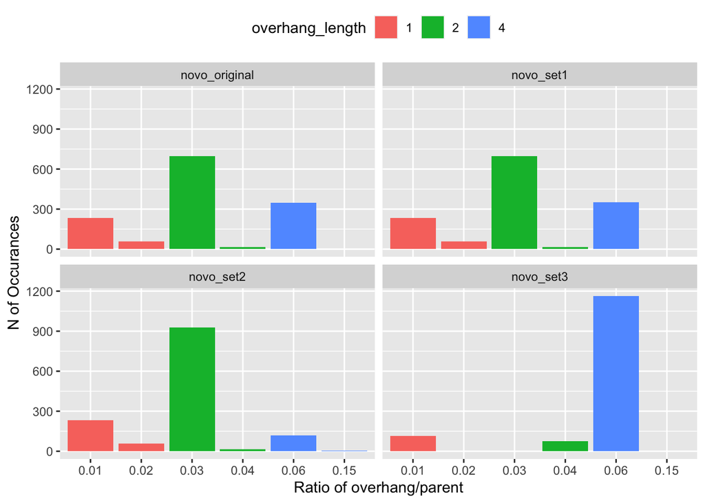

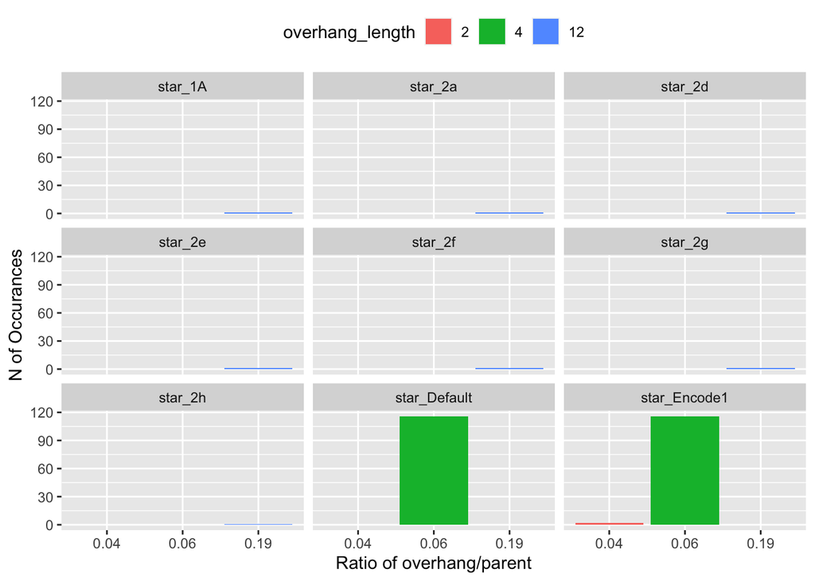

### Gap length

Summary plot of ratios of overhang/parent by the number of times they occur within the alignment variation, colored by the length of the gap observed. Only ratios under 0.5 are shown.

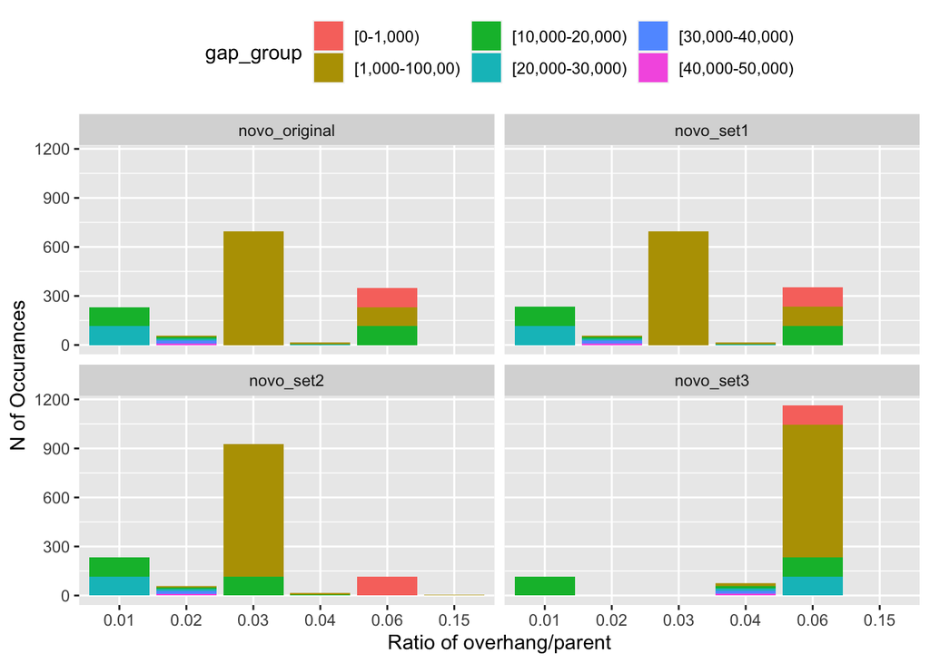

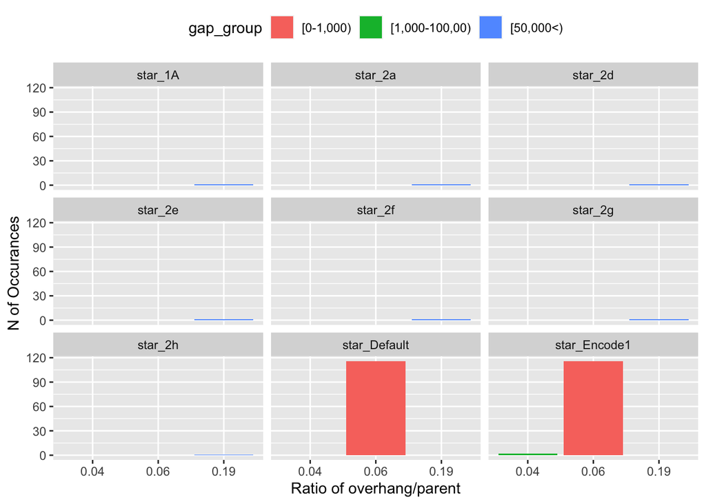

## Conclusion

NOVOAlign set three improves the overhang length, as seen through the increase in length from 2 to 4, as compared to the original as seen in the overhang length plots. However, this still cannot compare with the total number of these types of alignments (N=1380) to the worst STAR alignment output (star_encode1 N=125). STAR alignments based on the Busch paper (1A-C, 2A-I), including all reads (unique and multimapped average N=~7.6) are comparable to unique reads only (N=~7.3). Within the all reads alignments, the minimum overhang length of 12 is a significant improvement over the common overhang length of 2 in NOVOAlign. In addition, the majority of overhangs are 36bp in length. Similarly, STAR also decreases the length of the gap present between alignments, from NOVOAlign between 1,000 to 100,000 in NOVOAlign to 0-1,000 in STAR.

Of the remaining STAR parameters, the default settings and ENCODE settings did improve the overhang length and gap length over NOVOAlign. These two settings, however, did not improve either metric as compared to the settings provided by the Busch paper.

Based on these results, the Busch paper parameters appear to have optimized alignment of iCLIP data based on overhang length and gap length. Within the variations attempted, all reads can be included without interference to this metric. Additional testing will need to be completed to determine which Busch parameter set (2A-2I) is best suited for this pipeline based on additional metrics.